# test

David Sosa Olea

2024-01-25

```r
# Data completa
dim(model_data)
```

```
## [1] 4122    6
```

## Identificar valores atípicos utilizando la desviación estándar (SD)

Eliminar valores atípicos utilizando la desviación estándar (SD) es un enfoque común en estadística para identificar y tratar puntos de datos que se desvían significativamente de la media de un conjunto de datos. El método implica calcular la desviación estándar de los datos y eliminar los valores que están a una cierta distancia (múltiplos de la desviación estándar) de la media.

Aquí hay una descripción básica de cómo funciona este método:

Calcular la Media y la Desviación Estándar:

Se calcula la media (promedio) y la desviación estándar de los datos. Establecer un Umbral:

Se elige un múltiplo de la desviación estándar como umbral. Comúnmente, se utilizan múltiplos como 1, 1.5, 2, o 3, dependiendo de la rigurosidad que se desee aplicar. Identificar y Eliminar Valores Atípicos:

Se identifican los valores que están más allá del umbral establecido en ambos extremos de la distribución (por encima y por debajo de la media). Estos valores se consideran atípicos y se eliminan del conjunto de datos. Revisar y Validar:

Después de eliminar los valores atípicos, es importante revisar el conjunto de datos resultante y considerar si la exclusión de esos valores es justificada. En algunos casos, los valores atípicos pueden contener información importante o representar eventos genuinos. Es importante destacar que este método asume que los datos siguen una distribución normal.

```r
# Calcular la media y la desviación estándar de la columna 'price' en el DataFrame 'model_data'
mean_price <- mean(model_data$price, na.rm = T)  # Calcular la media, ignorando los valores NA
sd_price <- sd(model_data$price, na.rm = T)  # Calcular la desviación estándar, ignorando los valores NA

# Identificar los valores atípicos basados en la desviación estándar (3 veces la desviación estándar)
outliers <- model_data$price < (mean_price - 3 * sd_price) | model_data$price > (mean_price + 3 * sd_price)

# Crear un nuevo DataFrame 'model1_no_outliers_sd_method' sin los valores atípicos
model1_no_outliers_sd_method <- model_data[!outliers, ]

# Mostrar información sobre el nuevo DataFrame utilizando la función 'glimpse()'
model1_no_outliers_sd_method |> glimpse()
```

```
## Rows: 3,460
## Columns: 6
## $ year          <chr> "2023", "2023", "2023", "2023", "2023", "2023", "2023", …
## $ zipCode       <chr> "48221", "48221", "48221", "48221", "48221", "48221", "4…
## $ price         <int> 1000, 975, 1450, 1050, 1250, 1100, 1500, 1575, 1100, 120…
## $ bathrooms     <dbl> 1.0, 1.0, 2.0, 1.0, 1.0, 1.0, 1.0, 1.5, 1.0, 1.0, 1.5, 2…
## $ bedrooms      <int> 2, 2, 5, 2, 2, 2, 2, 3, 2, 2, 4, 3, 2, 1, 3, 3, 2, 3, 3,…
## $ squareFootage <int> 1295, 1000, 1188, 2262, 1000, 1148, 879, 1400, 1143, 105…
```

## Eliminar valores atipicos con el metodo IQR

Eliminar valores atípicos con el método IQR (rango intercuartílico) es otra técnica común en estadística. El rango intercuartílico es la diferencia entre el tercer cuartil (Q3) y el primer cuartil (Q1) de un conjunto de datos. Los valores atípicos se identifican y eliminan si están por debajo de Q1 - 1.5 * IQR o por encima de Q3 + 1.5 IQR. Aquí hay un ejemplo de cómo implementar esto en R:

```r
# Calcular el primer cuartil (Q1)
Q1 <- quantile(model_data$price, 0.25)

# Calcular el tercer cuartil (Q3)
Q3 <- quantile(model_data$price, 0.75)

# Calcular el rango intercuartílico (IQR)
IQR <- Q3 - Q1

# Identificar los valores atípicos utilizando el método IQR
outliers <- model_data$price < (Q1 - 1.5 * IQR) | model_data$price > (Q3 + 1.5 * IQR)

# Crear un nuevo DataFrame sin valores atípicos
model2_no_outliers_IQR_method <- model_data[!outliers, ]

# Mostrar información sobre el nuevo DataFrame sin valores atípicos
glimpse(model2_no_outliers_IQR_method)
```

```
## Rows: 3,310
## Columns: 6
## $ year          <chr> "2023", "2023", "2023", "2023", "2023", "2023", "2023", …
## $ zipCode       <chr> "48221", "48221", "48221", "48221", "48221", "48221", "4…
## $ price         <int> 1000, 975, 1450, 1050, 1250, 1100, 1500, 1575, 1100, 120…
## $ bathrooms     <dbl> 1.0, 1.0, 2.0, 1.0, 1.0, 1.0, 1.0, 1.5, 1.0, 1.0, 1.5, 2…
## $ bedrooms      <int> 2, 2, 5, 2, 2, 2, 2, 3, 2, 2, 4, 3, 2, 1, 3, 3, 2, 3, 3,…
## $ squareFootage <int> 1295, 1000, 1188, 2262, 1000, 1148, 879, 1400, 1143, 105…
```

## Usar método Robustos

El Método de Desviación Absoluta de la Mediana (Median Absolute Deviation, MAD) es un enfoque robusto utilizado para identificar valores atípicos en un conjunto de datos. A diferencia de otros métodos que dependen de la media y la desviación estándar, el MAD utiliza la mediana como medida central y evalúa la dispersión de los datos en términos de desviaciones absolutas respecto a la mediana.

```r
# Calcular la Desviación Absoluta de la Mediana (MAD)
MAD <- mad(model_data$price, constant = 1)

# Identificar valores atípicos utilizando el método robusto MAD
outliers <- abs(model_data$price - median(model_data$price)) / MAD > 2

# Crear un nuevo DataFrame sin valores atípicos utilizando el método robusto
model3_no_outliers_robust_method <- model_data[!outliers, ]

# Mostrar información sobre el nuevo DataFrame sin valores atípicos
model3_no_outliers_robust_method |> glimpse()
```

```
## Rows: 2,811
## Columns: 6
## $ year          <chr> "2023", "2023", "2023", "2023", "2023", "2023", "2023", …
## $ zipCode       <chr> "48221", "48221", "48221", "48221", "48221", "48221", "4…
## $ price         <int> 1000, 975, 1450, 1050, 1250, 1100, 1500, 1575, 1100, 120…
## $ bathrooms     <dbl> 1.0, 1.0, 2.0, 1.0, 1.0, 1.0, 1.0, 1.5, 1.0, 1.0, 1.5, 2…
## $ bedrooms      <int> 2, 2, 5, 2, 2, 2, 2, 3, 2, 2, 4, 3, 2, 1, 3, 3, 2, 3, 3,…
## $ squareFootage <int> 1295, 1000, 1188, 2262, 1000, 1148, 879, 1400, 1143, 105…
```

# Comprobación de linealidad

La comprobación de linealidad se refiere a la evaluación de la relación entre variables en un modelo estadístico o matemático para determinar si esta relación es lineal. En el contexto de análisis de regresión, la linealidad es una suposición fundamental. La comprobación de linealidad implica asegurarse de que la relación entre la variable dependiente y las variables independientes pueda ser bien aproximada mediante una línea recta.

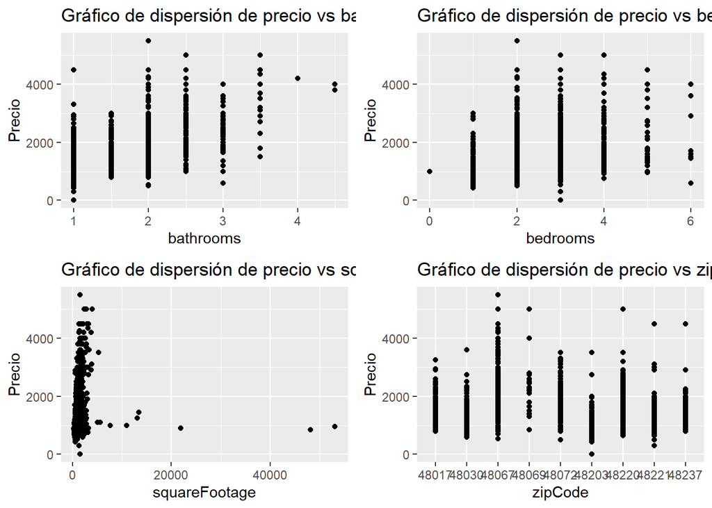

```r
# Lista de variables a incluir en los gráficos de dispersión
variables <- list("bathrooms", "bedrooms", "squareFootage", "zipCode")

# Función para crear gráficos de dispersión
create_scatter_plot_fun <- function(variables) {
    ggplot(model1_no_outliers_sd_method, aes(!!sym(variables), price)) +
        geom_point() +  # Añadir puntos al gráfico
        labs(title = paste("Gráfico de dispersión de precio vs", variables),
             x = variables,
             y = "Precio")
}

# Crear una lista de gráficos utilizando la función map
plots <- map(variables, create_scatter_plot_fun)

# Organizar los gráficos en una cuadrícula
grid.arrange(plots[[1]], plots[[2]], plots[[3]], plots[[4]], ncol = 2)
```

# Gráficos de Residuos

Los gráficos de residuos son herramientas visuales utilizadas en el análisis de regresión para evaluar la calidad del ajuste de un modelo a los datos observados. Los residuos son las diferencias entre los valores observados y los valores predichos por el modelo. Al examinar los patrones y distribuciones de estos residuos, se pueden identificar posibles violaciones de las suposiciones del modelo de regresión.

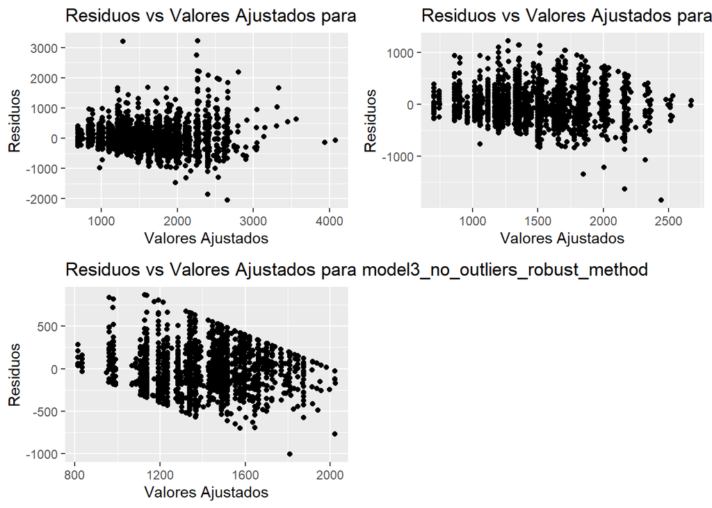

```r
# Lista de conjuntos de datos que contienen modelos sin valores atípicos
data_sets <- list(
    "model1_no_outliers_sd_method" = model1_no_outliers_sd_method,
    "model2_no_outliers_IQR_method" = model2_no_outliers_IQR_method,
    "model3_no_outliers_robust_method" = model3_no_outliers_robust_method
)

# Fórmula del modelo de regresión lineal
formula <- price ~ bathrooms + bedrooms + squareFootage + zipCode

# Ajustar modelos de regresión lineal a cada conjunto de datos
models <- map(data_sets, ~ lm(formula, data = .x))

# Función para crear gráficos de residuos vs valores ajustados
create_residuals_plot_fun <- function(model, model_name) {
  ggplot() +
    geom_point(aes(x = model$fitted.values, y = model$residuals)) +
    labs(
      title = paste("Residuos vs Valores Ajustados para", model_name),
      x = "Valores Ajustados",
      y = "Residuos"
    )
}

# Crear gráficos de residuos vs valores ajustados para cada modelo
plots <- map2(models, names(models), create_residuals_plot_fun)

# Organizar los gráficos en una cuadrícula de 2 columnas
grid.arrange(plots[[1]], plots[[2]], plots[[3]], ncol = 2)
```

## Normal Q - Q

Un Q-Q plot compara la distribución de los residuos con una distribución teórica (generalmente la distribución normal). Si los puntos del Q-Q plot siguen aproximadamente una línea diagonal, sugiere que los residuos se distribuyen de manera normal.

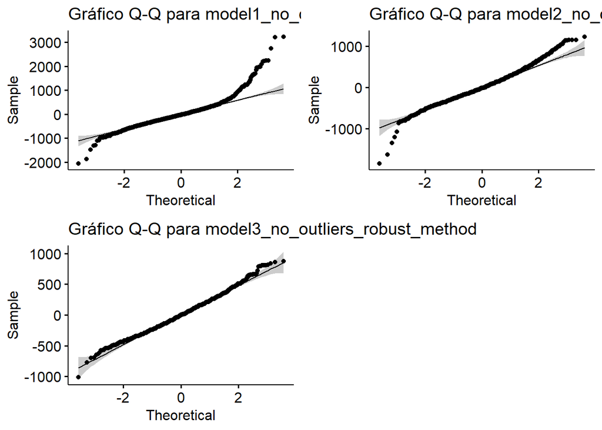

```r
# Lista de modelos de regresión lineal ajustados a conjuntos de datos específicos
models <- list(
  "model1_no_outliers_sd_method" = lm(price ~ bathrooms + bedrooms + squareFootage + zipCode, data = model1_no_outliers_sd_method),
  "model2_no_outliers_IQR_method" = lm(price ~ bathrooms + bedrooms + squareFootage + zipCode, data = model2_no_outliers_IQR_method),
  "model3_no_outliers_robust_method" = lm(price ~ bathrooms + bedrooms + squareFootage + zipCode, data = model3_no_outliers_robust_method)
)

# Función para crear gráficos Q-Q plot para los residuos de un modelo
create_qq_plot <- function(model_name, model) {
  residuals <- model$residuals
  qqplot <- ggqqplot(residuals) +
    ggtitle(paste("Gráfico Q-Q para", model_name))
  return(qqplot)
}

# Crear gráficos Q-Q plot para cada modelo
plots <- map2(names(models), models, create_qq_plot)

# Organizar los gráficos en una cuadrícula de 2 columnas usando plot_grid
combined_plot <- plot_grid(plotlist = plots, ncol = 2)
print(combined_plot)
```

# Coeficiente de correlación

El coeficiente de correlación es una medida estadística que cuantifica la relación lineal entre dos variables. En otras palabras, el coeficiente de correlación indica en qué medida las variaciones en una variable están asociadas con las variaciones en otra variable. Esta medida se utiliza comúnmente para evaluar la fuerza y dirección de la relación entre dos variables continuas.

Existen diferentes tipos de coeficientes de correlación, pero uno de los más comunes es el coeficiente de correlación de Pearson. El coeficiente de correlación de Pearson, denotado como “r”, tiene un rango de -1 a 1, donde:

- 1: Indica una correlación perfecta positiva. Esto significa que a medida que una variable aumenta, la otra variable también aumenta en una relación lineal perfecta.
- 0: Indica ausencia de correlación lineal. No hay relación lineal entre las dos variables.
- -1: Indica una correlación perfecta negativa. Esto significa que a medida que una variable aumenta, la otra variable disminuye en una relación lineal perfecta.

```r
# Calcular el coeficiente de correlación entre price y bathrooms
cor_bathrooms <- cor(model1_no_outliers_sd_method$price, model1_no_outliers_sd_method$bathrooms, use = "complete.obs")
print(paste("Coeficiente de correlación entre price y bathrooms:", cor_bathrooms))
```

```
## [1] "Coeficiente de correlación entre price y bathrooms: 0.611636865410224"
```

```r
# Calcular el coeficiente de correlación entre price y bedrooms
cor_bedrooms <- cor(model1_no_outliers_sd_method$price, model1_no_outliers_sd_method$bedrooms, use = "complete.obs")
print(paste("Coeficiente de correlación entre price y bedrooms:", cor_bedrooms))
```

```
## [1] "Coeficiente de correlación entre price y bedrooms: 0.269333937837847"
```

```r
# Calcular el coeficiente de correlación entre price y squareFootage
cor_squareFootage <- cor(model1_no_outliers_sd_method$price, model1_no_outliers_sd_method$squareFootage, use = "complete.obs")
print(paste("Coeficiente de correlación entre price y squareFootage:", cor_squareFootage))
```

```
## [1] "Coeficiente de correlación entre price y squareFootage: 0.09230062429832"
```

# Transformaciones de datos

Las transformaciones de datos, como tomar el logaritmo, la raíz cuadrada o elevar al cuadrado, son técnicas utilizadas en el análisis de datos por diversas razones. El propósito principal de estas transformaciones es modificar la distribución de los datos o la relación entre las variables para satisfacer las suposiciones de los métodos estadísticos o mejorar la interpretabilidad de los resultados. Aquí hay algunas razones comunes para realizar transformaciones:

- **Estabilizar la Varianza:**

En el análisis de regresión, se asume que la varianza de los errores es constante en todos los niveles de las variables predictoras. Si hay una relación no constante entre la varianza y las variables predictoras, las transformaciones como la raíz cuadrada o el logaritmo pueden ayudar a estabilizar la varianza.

- **Linearizar Relaciones No Lineales:**

En algunos casos, la relación entre las variables puede ser no lineal, pero los modelos estadísticos asumen una relación lineal. Tomar el logaritmo o la raíz cuadrada de una variable puede ayudar a linealizar la relación, permitiendo así que se apliquen modelos lineales.

- **Manejar Sesgo en la Distribución:**

Si los datos tienen una distribución sesgada hacia la derecha, donde hay valores atípicos que se encuentran en el extremo superior, tomar el logaritmo puede reducir el sesgo y hacer que la distribución sea más simétrica.

- **Escalamiento:**

Elevar al cuadrado o tomar la raíz cuadrada de una variable puede cambiar la escala de los datos, lo que puede ser útil para resaltar patrones o reducir la importancia de valores extremos.

- **Condiciones de Normalidad:**

En algunos métodos estadísticos, como las pruebas de hipótesis paramétricas, se asume la normalidad de los datos. Transformaciones como el logaritmo pueden ayudar a que los datos se aproximen más a una distribución normal.

- **Mejorar la Interpretabilidad:**

En ocasiones, realizar transformaciones puede hacer que los resultados sean más interpretables o más fácilmente comparables. Es importante señalar que la elección de una transformación específica depende de la naturaleza de los datos y de los objetivos del análisis. Además, se debe tener precaución al interpretar resultados transformados, ya que pueden afectar la interpretación de los coeficientes o las métricas de evaluación del modelo. La selección de una transformación adecuada a menudo implica explorar y comprender la naturaleza de los datos.

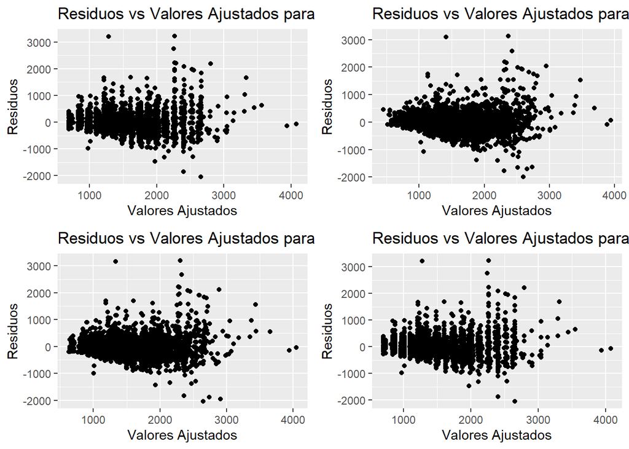

```r
# Crear un nuevo DataFrame con la transformación logarítmica de squareFootage
m1_log <- model1_no_outliers_sd_method |>
  mutate(squareFootage = log(squareFootage))

# Crear un nuevo DataFrame con la transformación de raíz cuadrada de squareFootage
m1_sqrt <- model1_no_outliers_sd_method |>
  mutate(squareFootage = sqrt(squareFootage))

# Crear un nuevo DataFrame con la transformación cuadrática de squareFootage
m1_sq2 <-  model1_no_outliers_sd_method |>
  mutate(squareFootage = (squareFootage)^2)

# Lista de modelos de regresión lineal con diferentes transformaciones de squareFootage
models <- list(
  "model_no_outliers_sd_method" = lm(price ~ bathrooms + bedrooms + squareFootage + zipCode, data = model1_no_outliers_sd_method),
  "ml_log" = lm(price ~ bathrooms + bedrooms + squareFootage + zipCode, data = m1_log),
  "m1_sqrt"= lm(price ~ bathrooms + bedrooms + squareFootage + zipCode, data = m1_sqrt),
  "m1_sq2" = lm(price ~ bathrooms + bedrooms + squareFootage + zipCode, data = m1_sq2)
)

# Función para crear gráficos de residuos vs valores ajustados
create_residuals_plot <- function(model_name, model) {
  ggplot() +
    geom_point(aes(x = model$fitted.values, y = model$residuals)) +
    labs(
      title = paste("Residuos vs Valores Ajustados para", model_name),
      x = "Valores Ajustados",
      y = "Residuos"
    )
}

# Crear gráficos de residuos vs valores ajustados para cada modelo
plots <- map2(names(models), models, create_residuals_plot)

# Organizar los gráficos en una cuadrícula de 2 columnas
grid.arrange(plots[[1]], plots[[2]], plots[[3]], plots[[4]], ncol = 2)
```

# Convertir a factores

En R, “convertir a factores” se refiere a cambiar el tipo de datos de una variable a un factor. Un factor es un tipo de dato en R que representa una variable categórica o cualitativa. Las variables categóricas toman un número limitado y fijo de valores que representan categorías o niveles, y no tienen un orden inherente entre ellos.

Cuando conviertes una variable a factor en R, estás indicando que la variable es categórica y que R debe tratarla como tal. Esto es útil cuando trabajas con variables que representan categorías como nombres de regiones, tamaños, colores, etc.

La función básica para convertir una variable a factor en R es **‘as.factor()’**

```r
# Imprimir la estructura de cada conjunto de datos en data_sets utilizando str()
map(data_sets, str)
```

```
## 'data.frame':    3460 obs. of  6 variables:
##  $ year         : chr  "2023" "2023" "2023" "2023" ...
##  $ zipCode      : chr  "48221" "48221" "48221" "48221" ...
##  $ price        : int  1000 975 1450 1050 1250 1100 1500 1575 1100 1200 ...
##  $ bathrooms    : num  1 1 2 1 1 1 1 1.5 1 1 ...
##  $ bedrooms     : int  2 2 5 2 2 2 2 3 2 2 ...
##  $ squareFootage: int  1295 1000 1188 2262 1000 1148 879 1400 1143 1058 ...
##  - attr(*, "na.action")= 'omit' Named int [1:656] 2 5 6 7 10 13 18 40 45 47 ...
##   ..- attr(*, "names")= chr [1:656] "2" "5" "6" "7" ...
## 'data.frame':    3310 obs. of  6 variables:
##  $ year         : chr  "2023" "2023" "2023" "2023" ...
##  $ zipCode      : chr  "48221" "48221" "48221" "48221" ...
##  $ price        : int  1000 975 1450 1050 1250 1100 1500 1575 1100 1200 ...
##  $ bathrooms    : num  1 1 2 1 1 1 1 1.5 1 1 ...
##  $ bedrooms     : int  2 2 5 2 2 2 2 3 2 2 ...
##  $ squareFootage: int  1295 1000 1188 2262 1000 1148 879 1400 1143 1058 ...
##  - attr(*, "na.action")= 'omit' Named int [1:656] 2 5 6 7 10 13 18 40 45 47 ...
##   ..- attr(*, "names")= chr [1:656] "2" "5" "6" "7" ...
## 'data.frame':    2811 obs. of  6 variables:
##  $ year         : chr  "2023" "2023" "2023" "2023" ...
##  $ zipCode      : chr  "48221" "48221" "48221" "48221" ...
##  $ price        : int  1000 975 1450 1050 1250 1100 1500 1575 1100 1200 ...
##  $ bathrooms    : num  1 1 2 1 1 1 1 1.5 1 1 ...
##  $ bedrooms     : int  2 2 5 2 2 2 2 3 2 2 ...
##  $ squareFootage: int  1295 1000 1188 2262 1000 1148 879 1400 1143 1058 ...
##  - attr(*, "na.action")= 'omit' Named int [1:656] 2 5 6 7 10 13 18 40 45 47 ...
##   ..- attr(*, "names")= chr [1:656] "2" "5" "6" "7" ...
```

```r
# Definir una función para convertir a factores ciertas columnas en un conjunto de datos
mutate_data_to_fct <- function(df) {
  # Utilizar la función mutate_at para aplicar as.factor a las columnas "zipCode" y "year"
  df <- df |> mutate_at(c("zipCode", "year"), as.factor)
  return(df)
}

# Aplicar la función mutate_data_to_fct a cada conjunto de datos en data_sets usando map
data_sets <- map(data_sets, mutate_data_to_fct)
# Imprimir la estructura de cada conjunto de datos en data_sets utilizando str()
map(data_sets, str)
```

```
## 'data.frame':    3460 obs. of  6 variables:
##  $ year         : Factor w/ 6 levels "2018","2019",..: 6 6 6 6 6 6 6 6 6 6 ...
##  $ zipCode      : Factor w/ 9 levels "48017","48030",..: 8 8 8 8 8 8 8 8 8 8 ...
##  $ price        : int  1000 975 1450 1050 1250 1100 1500 1575 1100 1200 ...
##  $ bathrooms    : num  1 1 2 1 1 1 1 1.5 1 1 ...
##  $ bedrooms     : int  2 2 5 2 2 2 2 3 2 2 ...
##  $ squareFootage: int  1295 1000 1188 2262 1000 1148 879 1400 1143 1058 ...
##  - attr(*, "na.action")= 'omit' Named int [1:656] 2 5 6 7 10 13 18 40 45 47 ...
##   ..- attr(*, "names")= chr [1:656] "2" "5" "6" "7" ...
## 'data.frame':    3310 obs. of  6 variables:
##  $ year         : Factor w/ 6 levels "2018","2019",..: 6 6 6 6 6 6 6 6 6 6 ...
##  $ zipCode      : Factor w/ 9 levels "48017","48030",..: 8 8 8 8 8 8 8 8 8 8 ...
##  $ price        : int  1000 975 1450 1050 1250 1100 1500 1575 1100 1200 ...
##  $ bathrooms    : num  1 1 2 1 1 1 1 1.5 1 1 ...
##  $ bedrooms     : int  2 2 5 2 2 2 2 3 2 2 ...
##  $ squareFootage: int  1295 1000 1188 2262 1000 1148 879 1400 1143 1058 ...
##  - attr(*, "na.action")= 'omit' Named int [1:656] 2 5 6 7 10 13 18 40 45 47 ...
##   ..- attr(*, "names")= chr [1:656] "2" "5" "6" "7" ...
## 'data.frame':    2811 obs. of  6 variables:
##  $ year         : Factor w/ 5 levels "2019","2020",..: 5 5 5 5 5 5 5 5 5 5 ...
##  $ zipCode      : Factor w/ 9 levels "48017","48030",..: 8 8 8 8 8 8 8 8 8 8 ...
##  $ price        : int  1000 975 1450 1050 1250 1100 1500 1575 1100 1200 ...
##  $ bathrooms    : num  1 1 2 1 1 1 1 1.5 1 1 ...
##  $ bedrooms     : int  2 2 5 2 2 2 2 3 2 2 ...
##  $ squareFootage: int  1295 1000 1188 2262 1000 1148 879 1400 1143 1058 ...
##  - attr(*, "na.action")= 'omit' Named int [1:656] 2 5 6 7 10 13 18 40 45 47 ...
##   ..- attr(*, "names")= chr [1:656] "2" "5" "6" "7" ...
```

# Partición de Datos

La partición de datos es una técnica común en estadísticas y aprendizaje automático que implica dividir un conjunto de datos en subconjuntos más pequeños para diversos propósitos, como entrenar modelos, validar modelos y evaluar su rendimiento. Las particiones de datos son fundamentales para garantizar la validez y la generalización de los modelos que se construyen.

```r
# Definir una función para dividir los datos en conjuntos de entrenamiento y prueba
split_data_fun <- function(df, var1, var2) {

    # Obtener los niveles únicos de las variables var1 y var2
    levels1 <- unique (df[[var1]])
    levels2 <- unique (df[[var2]])

    # Inicializar índices para conjuntos de entrenamiento y prueba
    training_indices <- c()
    testing_indices  <- c()

    # Iterar sobre los niveles de var1 y var2
    for (level1 in levels1) {
        for (level2 in levels2) {

            # Filtrar las filas que coinciden con los niveles actuales de var1 y var2
            rows <- which(df[[var1]] == level1 & df[[var2]] == level2)

            # Verificar si solo hay una instancia
            if (length(rows) < 2 ) {
                # Si solo hay una instancia, añadirla a los datos de entrenamiento
                training_indices <- c(training_indices, rows)
            } else {
                # Si hay más de una instancia, crear una partición de datos de entrenamiento y prueba
                partition <- createDataPartition(y = rows, p = 0.70, list = FALSE)
                training_indices <- c(training_indices, rows[partition])
                testing_indices <- c(testing_indices, rows[-partition])
            }
        }
    }

    # Devolver una lista con los conjuntos de entrenamiento y prueba
    list(
        training = df[training_indices, ],
        testing = df[testing_indices, ]
    )
}
```

```r
split_data_frames <- map(data_sets, ~ split_data_fun(.x, "year", "zipCode" ))
```

```r
model <- lm(price ~ year
            + bathrooms
            + bedrooms
            + squareFootage * zipCode,
            data = split_data_frames$model1_no_outliers_sd_method$training)

model2 <- lm(price ~ year
                 + bathrooms
                 + bedrooms
                 + squareFootage * zipCode,
             data = split_data_frames$model2_no_outliers_IQR_method$training)

model3 <- lm(price ~ year
                 + bathrooms
                 + bedrooms
                 + squareFootage * zipCode,
             data = split_data_frames$model3_no_outliers_robust_method$training)
```

```r
# Obtener resúmenes y estadísticas adicionales para los modelos

# Resumen del Modelo 1
summary_model  <- summary(model)

# Resumen del Modelo 2
summary_model2 <- summary(model2)

# Resumen del Modelo 3
summary_model3 <- summary(model3)

# Estadísticas adicionales del Modelo 1
glance_model  <- broom::glance(model)

# Estadísticas adicionales del Modelo 2
glance_model2 <- broom::glance(model2)

# Estadísticas adicionales del Modelo 3
glance_model3 <- broom::glance(model3)
```

```
##
## Call:
## lm(formula = price ~ year + bathrooms + bedrooms + squareFootage *
##     zipCode, data = split_data_frames$model1_no_outliers_sd_method$training)
##
## Residuals:
##     Min      1Q  Median      3Q     Max
## -3430.0  -182.1   -28.8   150.8  2950.7
##
## Coefficients:
##                              Estimate Std. Error t value Pr(>|t|)
## (Intercept)                 138.03371  371.79357   0.371 0.710472
## year2019                     64.25537  356.45745   0.180 0.856962
## year2020                     75.62463  356.35075   0.212 0.831953
## year2021                    175.41300  356.59011   0.492 0.622821
## year2022                    258.59531  356.16885   0.726 0.467878
## year2023                    317.09156  356.10814   0.890 0.373318
## bathrooms                   432.84566   16.86714  25.662  < 2e-16 ***
## bedrooms                    116.75835   10.81105  10.800  < 2e-16 ***
## squareFootage                 0.35167    0.10315   3.409 0.000662 ***
## zipCode48030                 61.64220  123.81175   0.498 0.618619
## zipCode48067                 97.60864  118.52601   0.824 0.410291
## zipCode48069               -173.54569  215.96022  -0.804 0.421705
## zipCode48072                230.98242  142.83210   1.617 0.105971
## zipCode48203               -326.73812  125.51829  -2.603 0.009293 **
## zipCode48220                347.77143  111.67232   3.114 0.001865 **
## zipCode48221                -70.90684  112.55344  -0.630 0.528763
## zipCode48237                169.50997  123.42061   1.373 0.169742
## squareFootage:zipCode48030   -0.30263    0.11739  -2.578 0.009994 **
## squareFootage:zipCode48067    0.22467    0.10856   2.070 0.038592 *
## squareFootage:zipCode48069    0.34682    0.15250   2.274 0.023035 *
## squareFootage:zipCode48072   -0.08831    0.13080  -0.675 0.499654
## squareFootage:zipCode48203   -0.22347    0.11054  -2.022 0.043323 *
## squareFootage:zipCode48220   -0.32644    0.10445  -3.125 0.001797 **
## squareFootage:zipCode48221   -0.35285    0.10332  -3.415 0.000648 ***
## squareFootage:zipCode48237   -0.34029    0.11224  -3.032 0.002455 **
## ---
## Signif. codes:  0 '***' 0.001 '**' 0.01 '*' 0.05 '.' 0.1 ' ' 1
##
## Residual standard error: 352.9 on 2483 degrees of freedom
## Multiple R-squared:  0.6632, Adjusted R-squared:  0.6599
## F-statistic: 203.7 on 24 and 2483 DF,  p-value: < 2.2e-16
```

[output not shown]

```r
# Obtener intervalos de confianza para los coeficientes de los modelos

# Intervalos de confianza del Modelo 1
confint_model  <- confint(model, level = 0.95)

# Intervalos de confianza del Modelo 2
confint_model2 <- confint(model2, level = 0.95)

# Intervalos de confianza del Modelo 3
confint_model3 <- confint(model3, level = 0.95)
```

[output not shown]

[output not shown]

[output not shown]

[figure not shown]

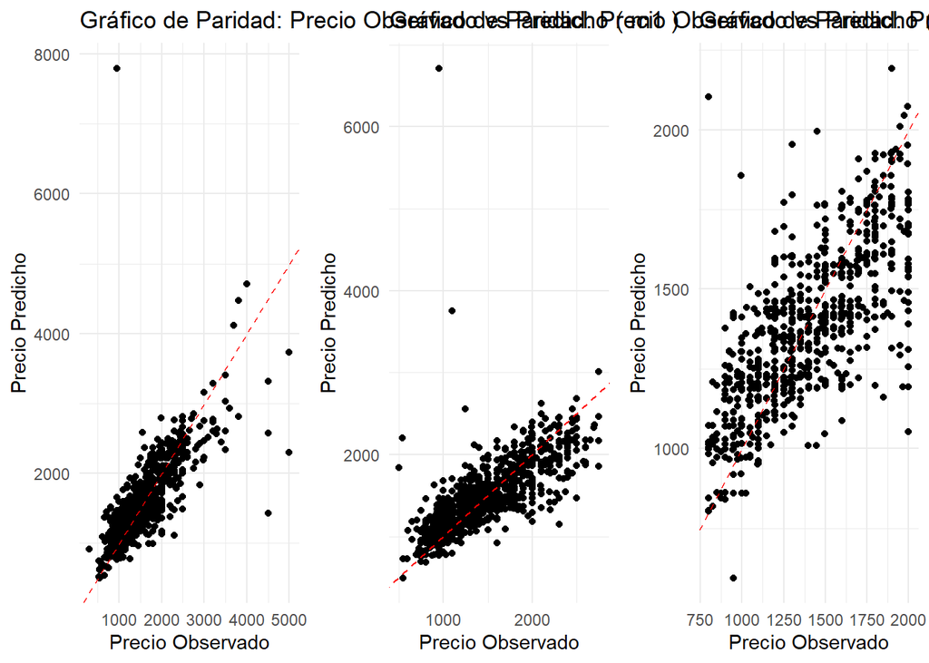

```r
# Crear una lista para el conjunto de prueba
datasets <- list(m1 = m1, m2 = m2, m3 = m3)

# Función para añadir predicciones a los datos
add_predictions <- function(dataset, model) {
    dataset$predicted <- predict(object = model, newdata = dataset)
    dataset
}

# Aplicar la función a cada combinación de conjunto de datos y modelo
datasets <- mapply(add_predictions, datasets, models, SIMPLIFY = FALSE)

# Función para crear gráficos de paridad
create_parity_plot <- function(dataset, name){
    ggplot(dataset, aes(x = price, y = predicted)) +
        geom_point() +
        geom_abline(intercept = 0, slope = 1, color = "red", linetype = "dashed") +
        labs(
            x = "Precio Observado",
            y = "Precio Predicho",
            title = paste("Gráfico de Paridad: Precio Observado vs Predicho (", name, ")")
        ) +
        theme_minimal()
}

# Aplicar la función de creación de gráficos a cada conjunto de datos
plots <- imap(datasets, ~ create_parity_plot(.x, .y))

# Imprimir o visualizar los gráficos individualmente para verificar si alguno causa el error

# Organizar los gráficos en una cuadrícula
grid.arrange(grobs = plots, ncol = 3)
```

```r
# Valores Predichos

calc_metrics <- function(dataset, model) {

    predictions <- predict(object = model, newdata = dataset)
    actuals     <- dataset$price # Reemplazar 'price' con el nombre de la variable de respuesta

    metrics <- list()

    # Cacula tus metricas aqui, luego asignalas a lista
    metrics$Model = deparse(substitute (model))
    metrics$MAE   = mae (actual = actuals, predicted = predictions)
    metrics$MSE   = mse (actual = actuals, predicted = predictions)
    metrics$RMSE  = rmse(actual = actuals, predicted = predictions)
    metrics$MAPE  = mape(actual = actuals, predicted = predictions)
    return(metrics)
}

results   <- map2(datasets, models, calc_metrics)

metrics_df <-  do.call(rbind, lapply(results, as.data.frame))
```

```
## $m1
## $m1$Model
## [1] ".y[[i]]"
##
## $m1$MAE
## [1] 232.748
##
## $m1$MSE
## [1] 156031.8
##
## $m1$RMSE
## [1] 395.0086
##
## $m1$MAPE
## [1] 0.1615483
##
##
## $m2
## $m2$Model
## [1] ".y[[i]]"
##
## $m2$MAE
## [1] 213.1982
##
## $m2$MSE
## [1] 119897.2
##
## $m2$RMSE
## [1] 346.2618
##
## $m2$MAPE
## [1] 0.1588389
##
##
## $m3
## $m3$Model
## [1] ".y[[i]]"
##
## $m3$MAE
## [1] 166.3931
##
## $m3$MSE
## [1] 48978.83
##
## $m3$RMSE
## [1] 221.3116
##
## $m3$MAPE
## [1] 0.125133
```

```
##      Model      MAE       MSE     RMSE      MAPE
## m1 .y[[i]] 232.7480 156031.81 395.0086 0.1615483
## m2 .y[[i]] 213.1982 119897.21 346.2618 0.1588389
## m3 .y[[i]] 166.3931  48978.83 221.3116 0.1251330
```

```r
# Almacenando los Resultados

model2_metrics <- metrics_df |> slice(2)

# intervalos de confianza

confint_df2  <-  as.data.frame(confint_model2)
confint_df2  <- confint_df2 |> rownames_to_column("Term")
m2_confint_tibble <- as_tibble(confint_df2)

# resultados del modelo

tidy_summary_model2  <- tidy(summary_model2)
model2_f             <- left_join(tidy_summary_model2,
                                  m2_confint_tibble, by = c("term" = "Term"))

write_rds(x = model2_f, file = "01_Informacion_Data/Models_Data/model2_f")
write_rds(x = tidy_summary_model2, file = "01_Informacion_Data/Models_Data/tidy_summary_model2")
```